# Neurofeedback training of spatial and feature-based attention: Statistical analysis

```r
# Set the model
mod = mod1
```

Once again, it looks like model 1 (the simpler model with matched variance across levels of congruence) has the better fit (when penalising for complexity). Next, we’ll run our simulation, using the winning model to sample from our 3 chains 5000 times each:

```r
# sample from model.
mod_sim = coda.samples(model=mod, variable.names=params, n.iter=5e3)
mod_csim = as.mcmc(do.call(rbind, mod_sim)) # combined chains

# display sample
summary(mod_sim)
```

```
##
## Iterations = 2001:7000
## Thinning interval = 1
## Number of chains = 3
## Sample size per chain = 5000
##
## 1. Empirical mean and standard deviation for each variable,
##    plus standard error of the mean:
##
##           Mean       SD  Naive SE Time-series SE
## mu[1]  0.01851 0.008212 6.705e-05      6.660e-05
## mu[2] -0.06348 0.008320 6.793e-05      6.821e-05
## sig    0.11682 0.004121 3.365e-05      3.391e-05
##
## 2. Quantiles for each variable:
##
##          2.5%      25%      50%      75%    97.5%
## mu[1]  0.0025  0.01292  0.01851  0.02410  0.03451
## mu[2] -0.0797 -0.06901 -0.06358 -0.05781 -0.04718
## sig    0.1090  0.11398  0.11670  0.11953  0.12520
```

It looks like on a whole, our model has recovered the means and standard deviations pretty well. Let’s plot the chains:

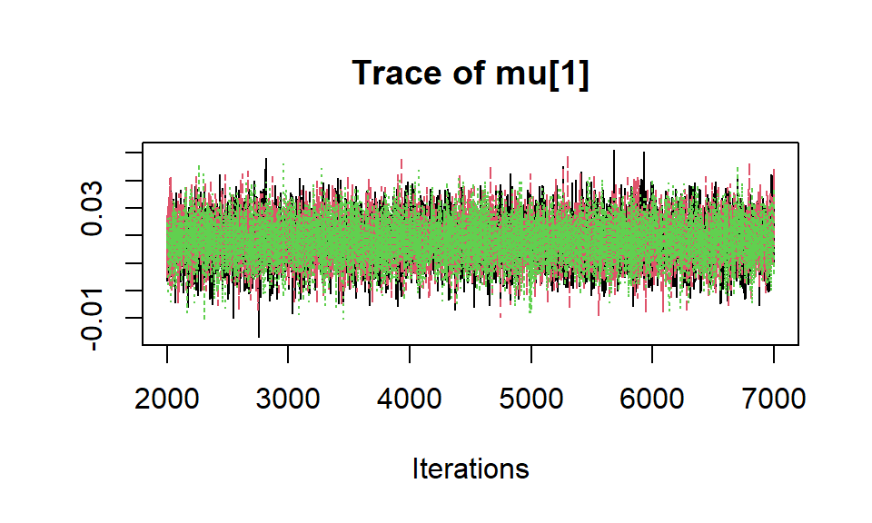

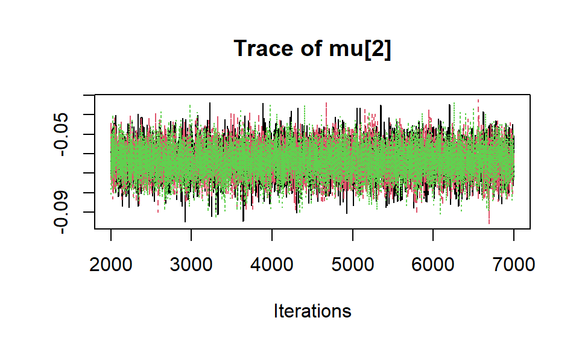

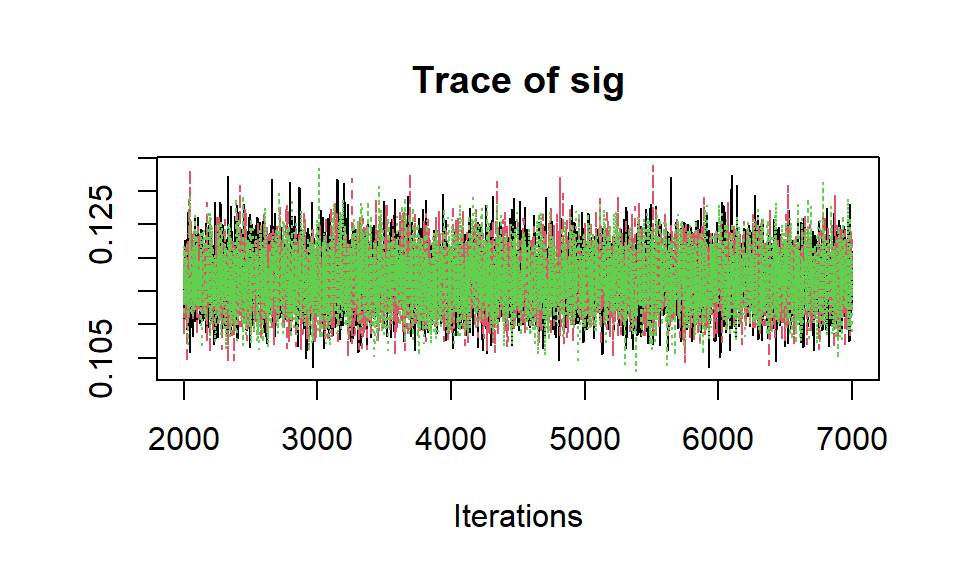

```r
# plot chains
traceplot(mod_sim)
```

The chains look to have converged well and don’t look auto correlated. Let’s run some diagnosics to be sure:

```r
gelman.diag(mod_sim)
```

```
## Potential scale reduction factors:
##
##       Point est. Upper C.I.
## mu[1]          1          1
## mu[2]          1          1
## sig            1          1
##
## Multivariate psrf
##
## 1
```

```r
autocorr.diag(mod_sim)
```

```
##               mu[1]       mu[2]          sig
## Lag 0   1.000000000 1.000000000  1.000000000
## Lag 1  -0.008334460 0.004582001  0.014835160
## Lag 5   0.018948347 0.001674846 -0.003358660
## Lag 10  0.004537718 0.007289212 -0.001319154
## Lag 50  0.008170025 0.008905088 -0.012164181
```

```r
cat('\n Effective sample sizes:\n')
```

```
##
##  Effective sample sizes:
```

```r
effectiveSize(mod_sim)
```

```
##    mu[1]    mu[2]      sig
## 15213.01 14923.08 14772.84
```

The Gelman statistics for all of our parameters are 1, suggesting the model has converged. The chains are not autocorrelated, suggesting we’ve thinned them enough, and the effective sample sizes are the same as the true sample size of 3 chains * 5000 samples = 15000. Thus, there are no major issues with our model fitting.

Finally, lets look at the residuals to evaluate if there are any obvious problems with the model choice:

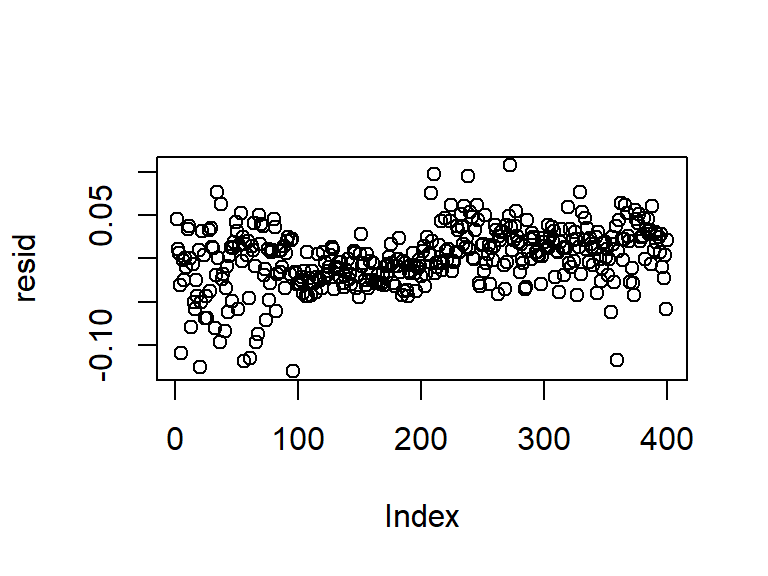

```r
# calculate parameter means
pm_params = colMeans(mod_csim)
yhat = pm_params[1:3][data_jags$grp]

# calculate reisduals
resid = data_jags$y - yhat

# plot the residuals
plot(resid)
```

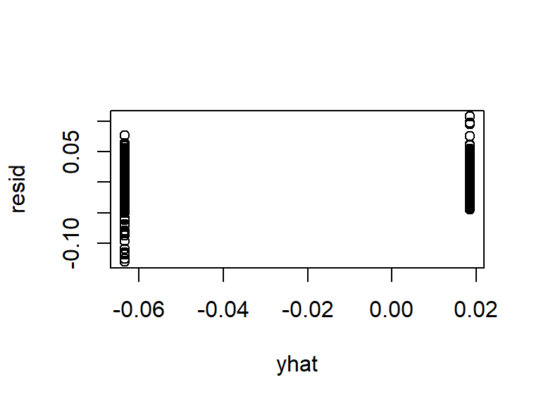

```r
plot(yhat, resid) # need to allow different variances across groups.
```

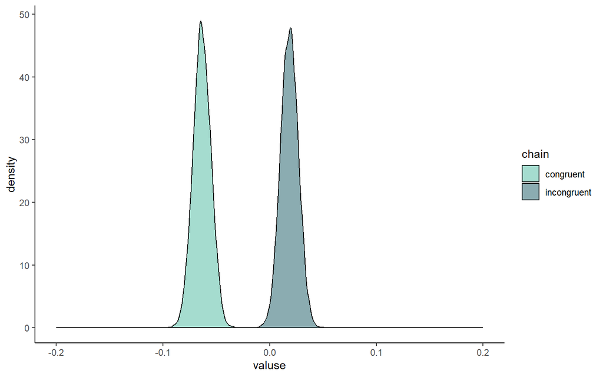

```r
darkteal = rgb(18 / 255, 47 / 255, 65 / 255)
medteal = rgb(5 / 255, 133 / 255, 134 / 255)

#Sample data
lightteal=rgb(0.298, 0.725,0.624)
medteal=rgb(0.09, 0.349, 0.388)
datplot <- data.frame(valuse = c(mod_csim[,1],mod_csim[,2]), chain = c(rep("incongruent", length(mod_csim[,1])), rep("congruent", length(mod_csim[,1]))))

#Plot.
plt=ggplot(datplot, aes(x = valuse, fill = chain)) + geom_density(alpha = 0.5) + scale_fill_manual( values = c(lightteal,medteal))
plt+ xlim(-0.2,0.2) + theme_classic()
```

It’s clear that participant’s task representations shifted toward the congruent experts’ and away from the incongruent experts. Lets get some metrics on this.

```
## HPD interval by parameter:
```

```
##              lower       upper
## mu[1]  0.002186101  0.03405317
## mu[2] -0.079077116 -0.04658401
## sig    0.109041421  0.12520117
## attr(,"Probability")
## [1] 0.95
```

```
## [1] 1
```

This represents extremely compelling evidence that active neurofeedback training is likely to lead to a shift toward the specific neural representation associated with good performance on the trained mode of attention.

### Specificity of behavioural training effects

Our analysis of the RSA data suggested that patterns of neural activity shifted in a manner that was specific to the type of neurofeedback training that was applied. Did this translate to specific behavioural training effects?

#### Select Data

To find out, we’ll begin by getting the data from our two active neurofeedback training conditions.

```r
behavedata_train_spft = behavedata_train[behavedata_train["AttentionTrained"]=="Space" | behavedata_train["AttentionTrained"]=="Feature", ]
behavedata_train_spft$AttentionTrained = factor(behavedata_train_spft$AttentionTrained)
```

Before we run any analysis, we’ll visualise the data:

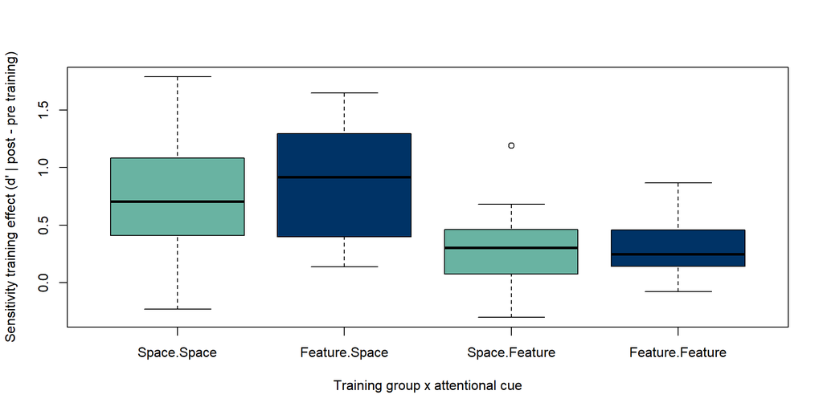

```r
# Plot
boxplot(Sensitivity_TrEfct ~ AttentionTrained*Attention.Type  , data = behavedata_train_spft, col=c("#69b3a2","#003366"), xlab = "Training group x attentional cue", ylab = "Sensitivity training effect (d' | post - pre training)")
```

It doesn’t look like there is any interaction between attentional cue-type and neurofeedback training type. Lets test that out statistically:

#### Specific behavioural training effects ANOVA

```r
# group data
data <- behavedata_train_spft %>% group_by(SubID, AttentionTrained, Attention.Type) %>% summarise(Sensitivity_TrEfct=mean(Sensitivity_TrEfct)) %>% as.data.frame()
# tests
DisplayANOVAResults2X2(formula = Sensitivity_TrEfct ~ AttentionTrained * Attention.Type, data=data, maineffectstringB = "Neurofeedback training group:", maineffectstringA = "Attention cue type:")
```

```
## Bayes factor analysis
## --------------
## [1] AttentionTrained                                                    : 0.2431822  ±0.01%
## [2] Attention.Type                                                      : 2558.996   ±0%
## [3] AttentionTrained:Attention.Type                                     : 0.2501861  ±0.01%
## [4] AttentionTrained + Attention.Type                                   : 622.6021   ±1.63%
## [5] AttentionTrained + AttentionTrained:Attention.Type                  : 0.08047703 ±1.01%
## [6] Attention.Type + AttentionTrained:Attention.Type                    : 860.0586   ±1.26%
## [7] AttentionTrained + Attention.Type + AttentionTrained:Attention.Type : 217.5104   ±4.42%
##
## Against denominator:
##   Intercept only
## ---
## Bayes factor type: BFlinearModel, JZS
##
##
##
## Interaction:
##
## Bayes factor analysis
## --------------
## [1] AttentionTrained + Attention.Type + AttentionTrained:Attention.Type : 0.3493569 ±4.71%
##
## Against denominator:
##   Sensitivity_TrEfct ~ AttentionTrained + Attention.Type
## ---
## Bayes factor type: BFlinearModel, JZS
##
##
##
##  Attention cue type:
##
## Bayes factor analysis
## --------------
## [1] AttentionTrained + Attention.Type + AttentionTrained:Attention.Type : 2702.763 ±4.53%
##
## Against denominator:
##   Sensitivity_TrEfct ~ AttentionTrained + AttentionTrained:Attention.Type
## ---
## Bayes factor type: BFlinearModel, JZS
##
##
##
##  Neurofeedback training group:
##
## Bayes factor analysis
## --------------
## [1] AttentionTrained + Attention.Type + AttentionTrained:Attention.Type : 0.2529018 ±4.6%
##
## Against denominator:
##   Sensitivity_TrEfct ~ Attention.Type + AttentionTrained:Attention.Type
## ---
## Bayes factor type: BFlinearModel, JZS
```

Thus, there is decisive evidence for a main effect of attentional cue type, such that participants improved more on the space cue than the feature cue. However, there is anecdotal evidence that this factor did not interact with the type of training participants received.

It therefore appears that while neurofeedback training had a specific effect on task-evoked neural activity, this did not translate to a specific behavioural training effect on the attentional task.

We’ll finish off by exporting some descriptive statistics to help us report this result.

```r
dat <- behavedata_train_spft %>% group_by(Attention.Type)
dat = dat %>% summarise(M=mean(Sensitivity_TrEfct), SD=sd(Sensitivity_TrEfct)) %>% as.data.frame()


# Show table data in markdown output
knitr::kable(dat, caption = "Specific sensitivity training effect (d' | Post training - Pre training)")
```

Specific sensitivity training effect (d’ | Post training - Pre training)

| Attention.Type | M | SD |
| --- | --- | --- |
| Space | 0.7805047 | 0.5212320 |
| Feature | 0.2840551 | 0.3035282 |